# Лабораторная работа №3

Настройка прав доступа

Юсупова К. Р.

Российский университет дружбы народов, Москва, Россия

# Информация

## Докладчик

- Юсупова Ксения Равилевна
- Российский университет дружбы народов
- Номер студенческого билета- 1132247531
- [1132247531@pfur.ru]

# Цель работы

Получение навыков настройки базовых и специальных прав доступа для групп пользователей в операционной системе типа Linux.

# Выполнение лабораторной работы

Созданы каталоги /data/main и /data/third с разными правами доступа. Владельцы каталогов изменены с root на группы main и third. Установлены разрешения, позволяющие владельцам записывать файлы и запрещающие доступ другим пользователям.

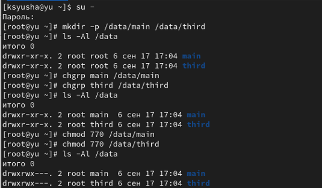

Выполнили пункты 1-4 из раздела 3.3.1 (Управление базовыми разрешениями)

## Выполнение лабораторной работы

В другом терминале перешли под учётную запись пользователя bob и перешли в каталог /data/main, создали файл emptyfile. В этом каталоге получилось успешно создать файл emptyfile создан, так как bob имеет права на выполнение (x) и запись (w) в каталоге. В каталоге /data/third было отказано в доступе, так как bob не имеет права на выполнение (x) для входа в этот каталог.

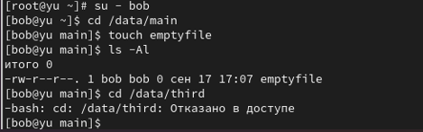

Выполнили пункты 5-7 из раздела 3.3.1 (Управление базовыми разрешениями)

## Выполнение лабораторной работы

Открыли новый терминал под пользователем alice и перешли в каталог /data/main. Создали два файла, владельцем которых является alice: touch alice1, touch alice2

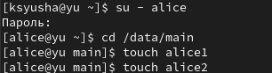

Выполнили пункты 1 и 2 из раздела 3.3.2 (Управление специальными разрешениями)

## Выполнение лабораторной работы

В другом терминале перешли под учётную запись пользователя bob и в каталог /data/main. Увидили два файла, созданные пользователем alice. Удалили файлы, принадлежащие пользователю alice; убедились что файлы будут удалены пользователем bob. Затем создали два файла, которые принадлежат пользователю bob: touch bob1, touch bob2

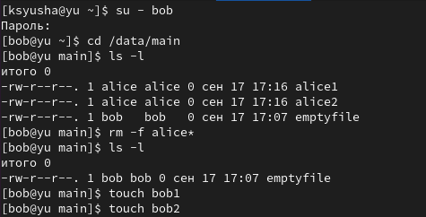

Выполнили пункты 3-5 из раздела 3.3.2 (Управление специальными разрешениями)

## Выполнение лабораторной работы

В терминале под пользователем root установили для каталога /data/main бит идентификатора группы, а также stiky-бит для разделяемого (общего) каталога группы

Выполнили пункт 6 из раздела 3.3.2 (Управление специальными разрешениями)

## Выполнение лабораторной работы

В терминале под пользователем alice создали в каталоге /data/main файлы alice3 и alice4; затем увидели, что два созданных вами файла принадлежат группе main, которая является группой-владельцем каталога /data/main. Пользователь alice не может удалить файлы bob благодаря sticky-bit. Новые файлы наследуют группу каталога благодаря SGID

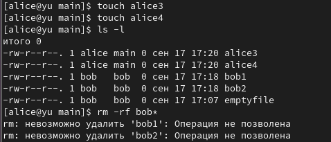

Выполнили пункты 7 и 8 из раздела 3.3.2 (Управление специальными разрешениями)

## Выполнение лабораторной работы

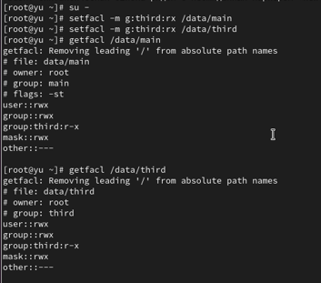

Выполнили пункты 1-3 из раздела 3.3.3 (Управление расширенными разрешениями с использованием списков ACL)

## Выполнение лабораторной работы

Создали новый файл с именем newfile1 в каталоге /data/main, затем использовали проверку текущих назначений полномочий. Созданы файлы до и после установки ACL. Файл newfile2 унаследовал ACL, newfile1 - нет.

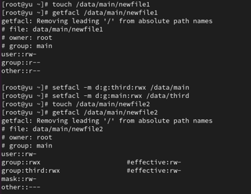

Выполнили пункты 4-7 из раздела 3.3.3 (Управление расширенными разрешениями с использованием списков ACL)

## Выполнение лабораторной работы

Проверили операции с файлами, и поняли что пользователь carol (группа third) может записывать в файл с ACL (newfile2), но не может удалять файлы из-за отсутствия прав на каталог

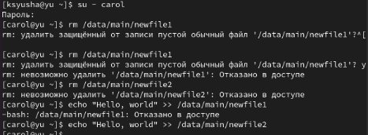

Выполнили пункт 8 из раздела 3.3.3 (Управление расширенными разрешениями с использованием списков ACL)

# Выводы

В ходе лабораторной работы мы получили навыки настройки базовых и специальных прав доступа для групп пользователей в операционной системе типа Linux.